# Mid-term project instructions

Author

Jonathan S. Cárdenas

# 1 Mid-term project GitHub repository URL:

https://github.com/JSCG95/2024dsa_midproject_group11.git

# 2 Instructions

This file contains both the **instructions** for the mid-term project and placeholders for your code. You are required to use this file to produce code, output, and answers to the questions below.

Besides simply creating output, make sure to interpret the output. You will need to create tables and/or plots to arrive at the answers, and then comment on what you found below it.

To get you setup, you will need to:

- Student #1: create a repository on your GitHub account. You can call this repository “2024dsa_midproject_groupX”, **where X is the number of your group**. Make it public, add a README, add a .gitignore for R.
- Student #1: follow the steps we did in class to start a new RStudio project with version control.
- Student #1: in your computer, create the sub-folders code, data, output, and move your data set into the `data` folder. Also, student 1 moves this current script into the `code` folder. Do a git stage, commit, push.
- Student #1: on GitHub, go the repository settings and invite your partner to be a collaborator in the repository. That will give them push permission.
- Now, both students should clone this repository on their computers like we did in class. Make sure this step works well and that you can pull and push from GitHub.
- Student 2, after cloning, does a git pull to get all these updates on their computer.
- Student 1 and 2 work together to update the README file. README files should explain what the repository is about, the goals of that project, who is working in it, and any other important details you may find.

# 3 Introduction

The convergence of remote sensing and computer vision promises to revolutionize plant research and crop monitoring by providing more efficient and insightful data collection methods within controlled environments like greenhouses. The true potential lies in the transformation of sensor-derived numerical representation of objects shapes or pixel intensities into meaningful parameters with biological relevance (Fahlgren et al. 2015).

# 4 Hypothesis and objectives

HYPOTHESIS: Lettuce fresh weight per plant is accurately estimated using canopy geometric features extracted using an RGB image analysis and machine learning models.

# 5 Material and Methods

## 5.2 Statistical analysis

# 6 Results

## 6.1 Exploratory Data Analysis (EDA)

```r
# Loading packages
library(tidyverse) # for data wrangling and plotting
library(janitor) # clean column names
library(knitr) # for figure displaying
library(car) # for Anova function
library(lme4)
library(broom) # for model residuals extraction
library(emmeans) # for model mean extraction
library(multcomp) # for pairwise comparison letter display
library(nlme) # for repeated measure correlation structures
library(ggridges)
library(ggcorrplot)
library(nlraa)
```

Loading data tables including remote sensed data, treatment factor columns, response variables (leaf fresh weight, leaf dry weight and leaf area), harvest dates.

```r
raw_data <- read_csv("../files/20-02_feat-matrix.csv")
wr_data <- raw_data %>%
  clean_names() %>%
  dplyr::select(-c("tipburn",'percent_tipburn',
                   "cum_dli","cf")) %>%
  na.omit()
```

Transform treatments into factors and create a new column where each treatment is specified. Set date as date format to calculate DAT.

```r
tr_date  <- mdy('10/18/2023')

wr_data <-wr_data %>%
  mutate(date = mdy(date),
         tray_id = factor(tray_id),
         light = factor(light),
         dat = as.factor(date - tr_date)
         ) %>%
  mutate(trtname = paste0(cultivar, '+',light)) %>%
  dplyr::select(-c(melatonin))
```

## 6.2 Boxplots: Response Variables distribution.

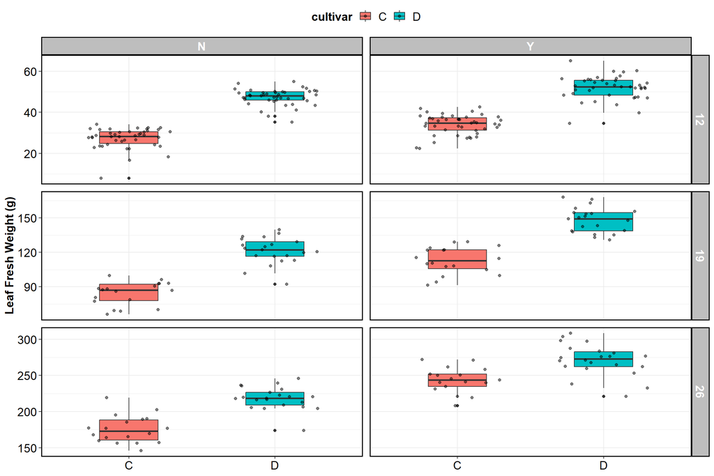

```r
wr_data %>%
  ggplot(aes(x = cultivar,
           y = lfw_g,
           fill = cultivar
           )
       ) +
  geom_boxplot(width = 0.4)+
  geom_jitter(alpha = 0.5,
              width = 0.3) +
  theme_bw()+
  facet_grid(dat~light,
             scales = 'free') +
  theme(plot.title = element_text(size=16,hjust = 0.5, face="bold"),
                   axis.text = element_text(size = 14,color="black"),
                   axis.title = element_text(size = 14, face="bold"),
                   legend.position = "top",
        legend.text = element_text(size = 14),  # Adjust legend text size
        legend.title = element_text(size = 14, face = 'bold'),
        panel.spacing = unit(.6, "lines"),
        panel.border = element_rect(color = "black", fill = NA, size = 1),
        strip.background = element_rect(fill = "gray", color = "black", size = 1),
    strip.text = element_text(size = 14, face = "bold", color = "white"))+
  labs(title=NULL,
       subtitle = NULL,
       caption=NULL,
       x=NULL,
       y="Leaf Fresh Weight (g)")
```

## 6.3 Response variables and predictors

To facilitate the analysis down this workflow, the original data set was divided into multiple data frames that contains all imaging features that will be used as potential predictors. Additionally, a data frame was created with all the response variables and predictors combined to implement an iterative step.

```r
predictors <- wr_data %>% dplyr::select(11:20)

response <- wr_data %>% dplyr::select(c('lfw_g'))

matrix <- predictors %>%
  mutate(lfw_g = response$lfw_g)

matrix_resp <- predictors %>%
  mutate(lfw_g = wr_data$lfw_g,
         ldw_g = wr_data$ldw_g,
         la_mm2 = wr_data$la_mm2)
```

## 6.4 Baseline model: Best Predictor

To determine what is the best image parameter that best explains the variability of the response, the coefficient of determination - R<sup>2</sup> was extracted from all possible linear regressions between 3 responses & 10 potential predictors. The image parameter showing the greatest value was used as the predictor for the baseline simple linear regression.

```r
r2_mods <- matrix_resp %>%
  # Pivotting longer for the response variables
  pivot_longer(cols = lfw_g:la_mm2,
               names_to = "resp_var",
               values_to = "resp_val"
               ) %>%
  # Pivotting longer for the explanatory variables
  pivot_longer(cols = perimeter:inc_light,
               names_to = "exp_var",
               values_to = "exp_val"
               ) %>%
  # Creating groups of resp_var and exp_var
  group_by(resp_var,exp_var) %>%
  nest() %>%
  # Applying linear model to each element
  mutate(lm = map(data,
                  ~lm(resp_val ~ exp_val,
                      data = .x
                      )
                  )) %>%
  # Extracting R2 for each element
  mutate(r2 = map(lm,
                  ~ summary(.x)$r.squared
                  )
         )

r2_mods
```

```
# A tibble: 30 × 5
# Groups:   resp_var, exp_var [30]
   resp_var exp_var      data               lm     r2
   <chr>    <chr>        <list>             <list> <list>
 1 lfw_g    perimeter    <tibble [324 × 2]> <lm>   <dbl [1]>
 2 lfw_g    axis_major   <tibble [324 × 2]> <lm>   <dbl [1]>
 3 lfw_g    axis_minor   <tibble [324 × 2]> <lm>   <dbl [1]>
 4 lfw_g    eccentricity <tibble [324 × 2]> <lm>   <dbl [1]>
 5 lfw_g    convex_hull  <tibble [324 × 2]> <lm>   <dbl [1]>
 6 lfw_g    compactness  <tibble [324 × 2]> <lm>   <dbl [1]>
 7 lfw_g    extent       <tibble [324 × 2]> <lm>   <dbl [1]>
 8 lfw_g    diameter     <tibble [324 × 2]> <lm>   <dbl [1]>
 9 lfw_g    area_cm2     <tibble [324 × 2]> <lm>   <dbl [1]>
10 lfw_g    inc_light    <tibble [324 × 2]> <lm>   <dbl [1]>
# ℹ 20 more rows
```

Only the features with the top 3 greatest R<sup>2</sup> values are shown.

```r
top_r2 <- r2_mods %>%
  unnest(r2) %>%
  group_by(resp_var)  %>%
  arrange(desc(r2),resp_var) %>%
  slice(1:3) %>%
  mutate(r2 = round(r2,3))
```

A data frame with the top 3 features per variable created above was used to generate scatterplots showing the potential predictor on the x-axis and the biomass response on the y-axis (fresh weight, dry weight or leaf area).

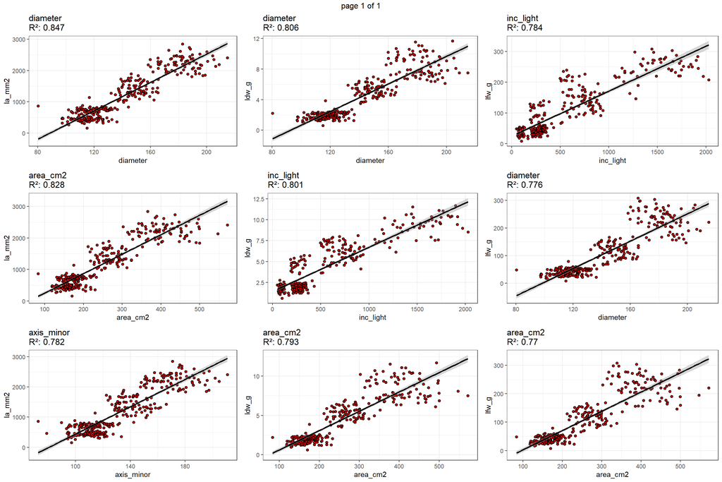

```r
lm_plots <- top_r2 %>%
  mutate(splot = map2(data,r2,
                      ~ ggplot(data = .x,
                               aes(x = exp_val,
                                   y = resp_val)
                               ) +
                        geom_point()+
                        geom_smooth(method = 'lm') +
                        labs(title = paste("R\u00B2",.y))

                      )
         ) %>%
  mutate(splot_better = pmap(
    list(.df = data,
         .r2 = r2,
         .rv = resp_var,
         .ev = exp_var
         ),
    function(.df,.r2,.rv,.ev)
      ggplot(data = .df,
                               aes(x = exp_val,
                                   y = resp_val)
                               ) +
                        geom_point(color = "black",
                                   shape = 21,
                                   size = 1.5,
                                   stroke = 0.7,
                                   fill = 'red3') +
                        geom_smooth(method = 'lm',
                                    color = "black") +
                        theme_bw() +
                        labs(title = paste(.ev,"\nR\u00B2:", .r2),

                             x = .ev,
                             y = .rv
                             )))

library(gridExtra)
linear_plots <- marrangeGrob(lm_plots$splot_better,
                         nrow = 3,
                         ncol = 3)
linear_plots
```

The following table summarizes the coefficient of determination (R<sup>2</sup>) values chosen for each response variable.

Top 3 predictors with the largest coefficient of determination values for the 3 responses variables

[output not shown]

## 6.5 Assumptions for the best predictor

Incident light showed the greatest R<sup>2</sup> to predict fresh biomass. This variable combines canopy area information with the amount of light received until a specific time point measured using a light sensor (cumulative DLI).

```r
options(contrasts = c("contr.sum", "contr.poly"))

# Model fitting: Because SR is numerical, will give us a slope.
lfw_lin<- lm(lfw_g ~ inc_light,
                 data = matrix_resp)

summary(lfw_lin)
```

```
Call:
lm(formula = lfw_g ~ inc_light, data = matrix_resp)

Residuals:
     Min       1Q   Median       3Q      Max
-113.441  -25.908   -8.675   17.964  133.400

Coefficients:
             Estimate Std. Error t value Pr(>|t|)
(Intercept) 24.427107   3.131900   7.799 8.73e-14 ***
inc_light    0.146542   0.004283  34.213  < 2e-16 ***
---
Signif. codes:  0 '***' 0.001 '**' 0.01 '*' 0.05 '.' 0.1 ' ' 1

Residual standard error: 37.6 on 322 degrees of freedom
Multiple R-squared:  0.7843,    Adjusted R-squared:  0.7836
F-statistic:  1171 on 1 and 322 DF,  p-value: < 2.2e-16
```

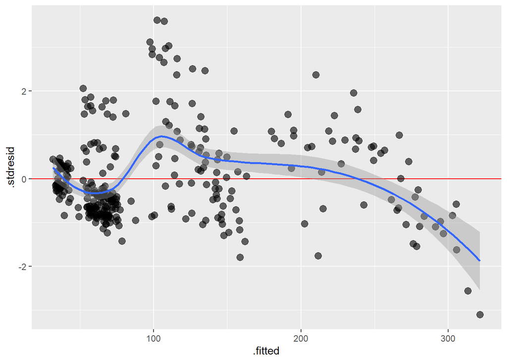

```r
lfw_lin_aug <- augment(lfw_lin) %>%
  mutate(.stdresid = rstudent(lfw_lin))

ggplot(lfw_lin_aug,
       aes(x = .fitted,
           y = .stdresid))+
  geom_hline(yintercept = 0, color = "red")+
  geom_point(size = 3, alpha = .6)+
  geom_smooth()
```

## 6.6 Linear or non - linear?

Destructive measurements and remote sensed data were captured at 3 time points along the crop cycle. As the objective is to fit a single model that predicts biomass on any given day, the right linear or non-linear fit between the best predictor must be found.

```r
options(contrasts = c("contr.sum", "contr.poly"))

# Model fitting: Because SR is numerical, will give us a slope.
lfw_quad<- lm(lfw_g ~ inc_light + I(inc_light^2) ,
                 data = matrix_resp)
summary(lfw_quad)
```

```
Call:
lm(formula = lfw_g ~ inc_light + I(inc_light^2), data = matrix_resp)

Residuals:
   Min     1Q Median     3Q    Max
-82.51 -25.39  -7.88  21.00 122.94

Coefficients:
                 Estimate Std. Error t value Pr(>|t|)
(Intercept)     5.868e+00  4.508e+00   1.302    0.194
inc_light       2.254e-01  1.487e-02  15.152  < 2e-16 ***
I(inc_light^2) -4.560e-05  8.272e-06  -5.513 7.26e-08 ***
---
Signif. codes:  0 '***' 0.001 '**' 0.01 '*' 0.05 '.' 0.1 ' ' 1

Residual standard error: 35.99 on 321 degrees of freedom
Multiple R-squared:  0.8029,    Adjusted R-squared:  0.8017
F-statistic: 653.9 on 2 and 321 DF,  p-value: < 2.2e-16
```

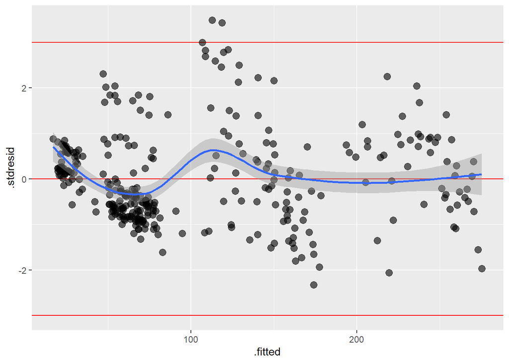

```r
lfw_quad_aug <- augment(lfw_quad) %>%
  mutate(.stdresid = rstudent(lfw_quad))

ggplot(lfw_quad_aug,
       aes(x = .fitted,
           y = .stdresid))+
  geom_hline(yintercept = 0, color = "red")+
  geom_hline(yintercept = c(-3,3), color = "red")+
  geom_point(size = 3, alpha = .6)+
  geom_smooth()
```

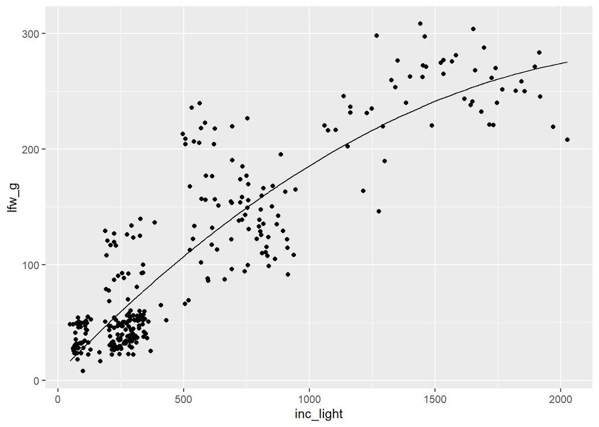

```r
ggplot(data = matrix_resp, aes(x = inc_light, y = lfw_g)) +
geom_point() +
geom_line(aes(y = fitted(lfw_quad)))
```

```r
lfw_log = nls(lfw_g ~ SSlogis(inc_light, a, b,c),
            data = matrix_resp)

summary(lfw_log)
```

```
Formula: lfw_g ~ SSlogis(inc_light, a, b, c)

Parameters:
  Estimate Std. Error t value Pr(>|t|)
a  265.030      8.248   32.13   <2e-16 ***
b  670.227     31.617   21.20   <2e-16 ***
c  321.267     20.574   15.62   <2e-16 ***
---
Signif. codes:  0 '***' 0.001 '**' 0.01 '*' 0.05 '.' 0.1 ' ' 1

Residual standard error: 35.75 on 321 degrees of freedom

Number of iterations to convergence: 2
Achieved convergence tolerance: 8.527e-06
```

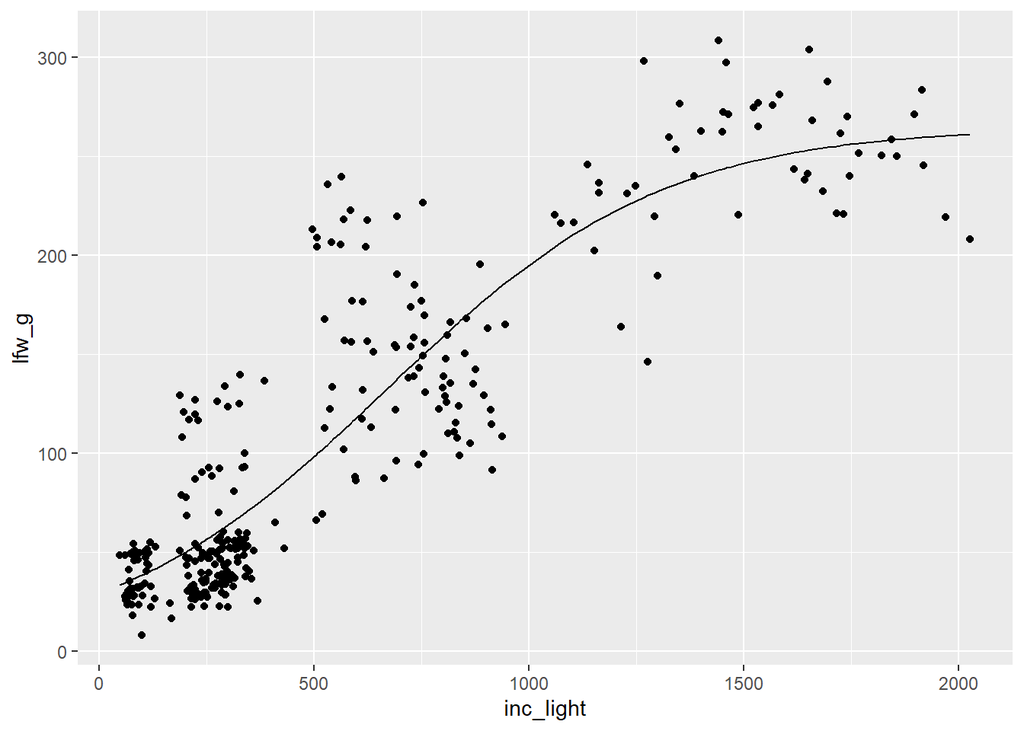

```r
ggplot(data = matrix_resp, aes(x = inc_light, y = lfw_g)) +
geom_point() +
geom_line(aes(y = fitted(lfw_log)))
```

```r
lfw_log_aug <- augment(lfw_log) %>%
  mutate(.stdresid = resid(lfw_log,
                           type = "pearson",
                           scaled = T))
```

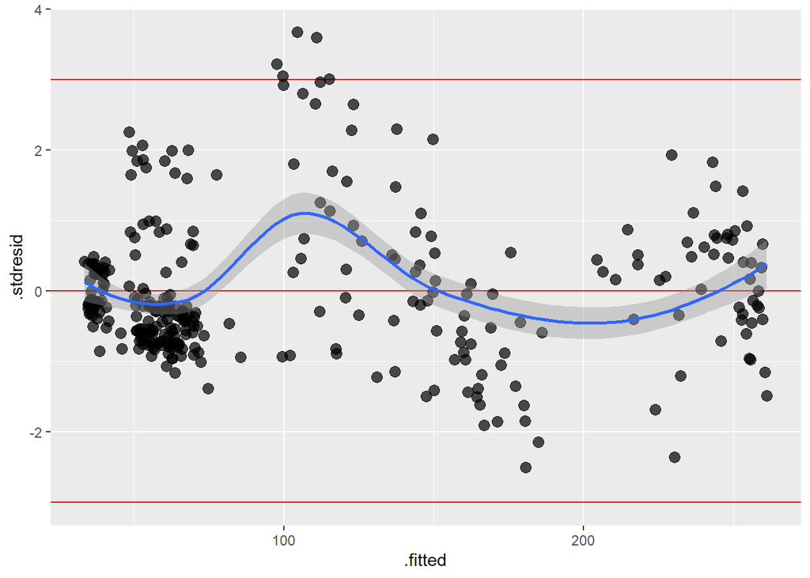

```r
ggplot(lfw_log_aug,
       aes(x = .fitted,
           y = .stdresid))+
  geom_hline(yintercept = 0, color = "red")+
  geom_hline(yintercept = c(-3,3), color = "red")+
  geom_point(size = 3, alpha = .7)+
  geom_smooth()
```

## 6.7 Correlations among predictors

To assess a potential risk of multicollinearity among predictors, a correlation matrix based on Pearson’s Correlation Coefficient (r) is plotted to check how linearly correlated the potential predictors are.

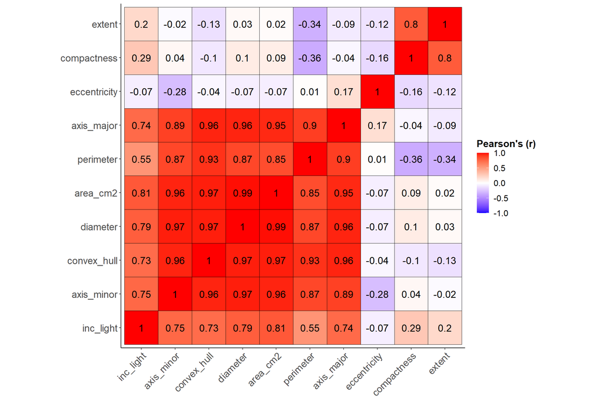

```r
corr_percent <- round(cor(predictors),2)
p.mat <- cor_pmat(predictors)

ggcorrplot(corr_percent, hc.order = TRUE,
           ggtheme = theme_classic(),
           legend.title = "Pearson's (r) " ,
           outline.color = "black",
           type = "full",
           lab = TRUE,
           lab_size = 5,
           tl.cex = 14,
           tl.col = "black") +
    theme(legend.title = element_text(size=14, face = "bold"),
          legend.text = element_text(size=12))
```

## 6.8 Modelling

### 6.8.1 Multiple Linear Regression

```r
lm(lfw_g ~ ., data  = matrix) %>%
  vif()
```

```
   perimeter   axis_major   axis_minor eccentricity  convex_hull  compactness
   28.418520   227.034710   262.134355    12.757339    85.447816    10.484552
      extent     diameter     area_cm2    inc_light
    2.919177   623.008848    58.191937     3.902768
```

```r
lm(lfw_g ~ inc_light + perimeter + compactness + extent + eccentricity, data  = matrix) %>%
  vif()
```

```
   inc_light    perimeter  compactness       extent eccentricity
    2.389637     2.548078     3.574595     2.797381     1.030665
```

Make sure to run a model that reflects your study design. Even if your study design does not include one of the designs covered in class, you are still expected to run the most appropriate model. If you need help for references, let me know.

Before each chunk, describe the steps being performed in that chunk. For example, “Here I will load the data”.

If a chunk produces output, like printing a data frame, statistical summary, a plot, ANOVA table, etc., make sure to write text interpreting what you see and how you can/will use that information to move forward to the next steps in the workflow.

# 7 Team work in GitHub

Whether you are working with your future-self or as duos, make sure to stage, commit, and push after finishing each of the sub-sections above. When committing, write commit messages that are short and descriptive (e.g., finished wrangling).

If you are working in duos, make sure to split the workload. I will check your collaborative work through the commit history, and if one student has contributed significantly more than the other, than that will impact grades.

**Tip 1**: to avoid merge conflicts, make sure to **pull** first, and then start working locally. That will ensure that any changes made by your partner will be “downloaded” before you make changes to the files locally.

**Tip 2**: make use of the Issues on this repository to set up to-do lists and assign tasks to different people. You can also use each issue/task to discuss how things should be run and get to an agreement.

# 8 Submitting your work

Once you have developed all the code and answers, make sure to Render this quarto file.

**Notes on rendering**:

- Make sure to render your work and inspect how the final html look like.
- If it does not look professional for whatever reason, then fix the issue, re-render it, recheck.
- Only send me your work once your html file looks professional.
- Some potential issues you may encounter and how to fix them:
  - Some times your code may be creating a table output that is waaay to long and cumbersome to scroll through when rendered. If this is the case, make it more professional looking by using the `head()` function to only print the first handful of rows (instead of thousands of rows).
  - **DO NOT** delete the file’s heading levels (# and ##). They set up the proper heading 1 and 2 levels, and I use them to guide my grading.
  - If a given chunk is also outputting warnings or messages, inhibit this behavior by changing the chunk options `message` and `warning` to `FALSE`.
  - If, after rendered, 2 lines of text are connected and you wish to “break line” between them, add 2 extra spaces after the first one.

After rendering, an .html file will be created on your `code` folder.

Rename this file to `LASTNAME1-LASTNAME2_midtermproject.html`.  
For ex., `Bastos-Mendes_midtermproject.html`.

Send the html file to my email (lmbastos@uga.edu) by **April 11th** 11:59 pm.

## References

De Vylder, Jonas, Filip Vandenbussche, Yuming Hu, Wilfried Philips, and Dominique Van Der Straeten. 2012. “Rosette Tracker: An Open Source Image Analysis Tool for Automatic Quantification of Genotype Effects.” *Plant Physiology* 160 (3): 1149–59. https://doi.org/10.1104/pp.112.202762.

Fahlgren, Noah, Maximilian Feldman, Malia A. Gehan, Melinda S. Wilson, Christine Shyu, Douglas W. Bryant, Steven T. Hill, et al. 2015. “A Versatile Phenotyping System and Analytics Platform Reveals Diverse Temporal Responses to Water Availability in Setaria.” *Molecular Plant* 8 (10): 1520–35. https://doi.org/10.1016/j.molp.2015.06.005.

Mochida, Keiichi, Satoru Koda, Komaki Inoue, Takashi Hirayama, Shojiro Tanaka, Ryuei Nishii, and Farid Melgani. 2019. “Computer Vision-Based Phenotyping for Improvement of Plant Productivity: A Machine Learning Perspective.” *GigaScience* 8 (1): giy153. https://doi.org/10.1093/gigascience/giy153.